# R Recitation - 6 January: Correlation (Parametric & Non-Parametric) + Linear Regression (Full Walkthrough)

Burcu

06 January 2026

# 1 Learning goals

By the end of this recitation, you should be able to:

1. Compute and interpret correlation using:
   - Pearson (parametric)
   - Spearman and Kendall (non-parametric)
2. Build a linear regression model step-by-step in R:
   - Specify the model
   - Inspect coefficients and model fit
   - Compare nested models
3. Diagnose regression assumptions and common problems:
   - Linearity
   - Independence (conceptual + when it matters)
   - Homoscedasticity
   - Normality of residuals
   - Outliers and influential observations
   - Multicollinearity (for multiple regression)
4. Report results clearly using standard statistics language.

# 2 Correlation (briefly)

## 2.1 Why start with a plot?

Correlation is a number, but *relationships are visual*. Always start with a scatterplot.

We’ll work with a small simulated example to illustrate all methods cleanly.

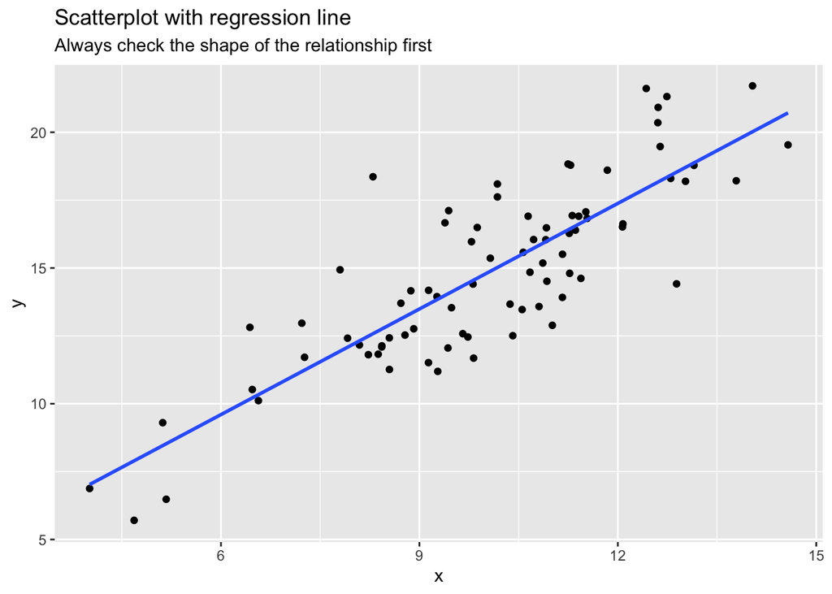

```r
set.seed(42)
n <- 80

# Create an x variable

x <- rnorm(n, mean = 10, sd = 2)

# Create a y variable with a roughly linear relationship + noise

y <- 3 + 1.2 * x + rnorm(n, mean = 0, sd = 2)

df_corr <- tibble(x = x, y = y)

ggplot(df_corr, aes(x, y)) +
geom_point() +
geom_smooth(method = "lm", se = FALSE) +
labs(title = "Scatterplot with regression line",
subtitle = "Always check the shape of the relationship first")
```

## 2.2 Pearson correlation (parametric)

Pearson correlation measures *linear association* between two continuous variables.

### 2.2.1 Typical conditions (practical framing)

- The relationship is approximately linear.
- Extreme outliers can distort Pearson strongly.
- Normality is not a strict requirement for using Pearson in all cases, but it matters more for small samples and for inference.

```r
cor(df_corr$x, df_corr$y, method = "pearson")
```

```
## [1] 0.8364027
```

```r
cor.test(df_corr$x, df_corr$y, method = "pearson")
```

```
##
##  Pearson's product-moment correlation
##
## data:  df_corr$x and df_corr$y
## t = 13.477, df = 78, p-value < 2.2e-16
## alternative hypothesis: true correlation is not equal to 0
## 95 percent confidence interval:
##  0.7555312 0.8921649
## sample estimates:
##       cor
## 0.8364027
```

### 2.2.2 How to report (template)

“There was a (positive/negative) linear association between X and Y, Pearson’s r(df) = …, p = …, 95% CI […, …].”

## 2.3 Spearman and Kendall (non-parametric)

Non-parametric correlation is useful when:

- The relationship is monotonic but not linear,
- The data are ordinal, or
- You want a rank-based measure less sensitive to outliers / non-normality.

### 2.3.1 Spearman (rank correlation; monotonic relationships)

```r
cor(df_corr$x, df_corr$y, method = "spearman")
```

```
## [1] 0.7943741
```

```r
cor.test(df_corr$x, df_corr$y, method = "spearman", exact = FALSE)
```

```
##
##  Spearman's rank correlation rho
##
## data:  df_corr$x and df_corr$y
## S = 17544, p-value < 2.2e-16
## alternative hypothesis: true rho is not equal to 0
## sample estimates:
##       rho
## 0.7943741
```

### 2.3.2 Kendall (based on concordant/discordant pairs; robust in small n / ties)

```r
cor(df_corr$x, df_corr$y, method = "kendall")
```

```
## [1] 0.6101266
```

```r
cor.test(df_corr$x, df_corr$y, method = "kendall", exact = FALSE)
```

```
##
##  Kendall's rank correlation tau
##
## data:  df_corr$x and df_corr$y
## z = 8.0102, p-value = 1.145e-15
## alternative hypothesis: true tau is not equal to 0
## sample estimates:
##       tau
## 0.6101266
```

## 2.4 Quick comparison: when to use which?

- **Pearson**: linear association, continuous variables, no severe outliers, interpretability in linear units is aligned with regression.
- **Spearman**: monotonic association (not necessarily linear), ordinal data, more robust to non-normality and some outliers.
- **Kendall**: similar goals as Spearman; can be preferable with small samples and many ties.

## 2.5 Chi-square Test

### 2.5.1 What question does the chi-square test answer?

The chi-square test of independence examines whether two categorical variables are statistically associated.

Conceptually, this is the categorical analogue of correlation: - Correlation → association between continuous variables - Chi-square → association between categorical variables

```r
dat <- as.data.frame(Titanic)

# Class × Survival
tbl <- xtabs(Freq ~ Class + Survived, data = dat)
tbl
```

```
##       Survived
## Class   No Yes
##   1st  122 203
##   2nd  167 118
##   3rd  528 178
##   Crew 673 212
```

```r
chisq.test(tbl)
```

```
##
##  Pearson's Chi-squared test
##
## data:  tbl
## X-squared = 190.4, df = 3, p-value < 2.2e-16
```

```r
chisq.test(tbl)$expected
```

```
##       Survived
## Class        No       Yes
##   1st  220.0136 104.98637
##   2nd  192.9350  92.06497
##   3rd  477.9373 228.06270
##   Crew 599.1140 285.88596
```

### 2.5.2 Assumptions of the chi-square test

- Observations are independent
- Expected cell counts should generally be ≥ 5

When expected counts are small, the chi-square approximation may be inaccurate.

### 2.5.3 Fisher’s Exact Test (small samples)

When expected cell counts are small, Fisher’s Exact Test is preferred.

```r
fisher.test(tbl, simulate.p.value = TRUE, B = 20000)
```

```
##
##  Fisher's Exact Test for Count Data with simulated p-value (based on
##  20000 replicates)
##
## data:  tbl
## p-value = 5e-05
## alternative hypothesis: two.sided
```

# 3 Linear regression (walkthrough)

Regression is not just “a line”: it is a *model* that explains/predicts an outcome using one or more predictors, and it comes with assumptions we must check.

We will use a real dataset (`mtcars`) for a concrete end-to-end demonstration.

## 3.1 Data and question

We will model fuel efficiency (`mpg`) using:

- `wt` (car weight)
- `hp` (horsepower)

**Question:** How do weight and horsepower relate to miles per gallon?

```r
df <- mtcars %>%
as_tibble(rownames = "car") %>%
select(car, mpg, wt, hp, cyl)

glimpse(df)
```

```
## Rows: 32
## Columns: 5
## $ car <chr> "Mazda RX4", "Mazda RX4 Wag", "Datsun 710", "Hornet 4 Drive", "Hor…
## $ mpg <dbl> 21.0, 21.0, 22.8, 21.4, 18.7, 18.1, 14.3, 24.4, 22.8, 19.2, 17.8, …
## $ wt  <dbl> 2.620, 2.875, 2.320, 3.215, 3.440, 3.460, 3.570, 3.190, 3.150, 3.4…
## $ hp  <dbl> 110, 110, 93, 110, 175, 105, 245, 62, 95, 123, 123, 180, 180, 180,…
## $ cyl <dbl> 6, 6, 4, 6, 8, 6, 8, 4, 4, 6, 6, 8, 8, 8, 8, 8, 8, 4, 4, 4, 4, 8, …
```

```r
summary(df)
```

```
##      car                 mpg              wt              hp
##  Length:32          Min.   :10.40   Min.   :1.513   Min.   : 52.0
##  Class :character   1st Qu.:15.43   1st Qu.:2.581   1st Qu.: 96.5
##  Mode  :character   Median :19.20   Median :3.325   Median :123.0
##                     Mean   :20.09   Mean   :3.217   Mean   :146.7
##                     3rd Qu.:22.80   3rd Qu.:3.610   3rd Qu.:180.0
##                     Max.   :33.90   Max.   :5.424   Max.   :335.0
##       cyl
##  Min.   :4.000
##  1st Qu.:4.000
##  Median :6.000
##  Mean   :6.188
##  3rd Qu.:8.000
##  Max.   :8.000
```

## 3.2 First: visualize relationships

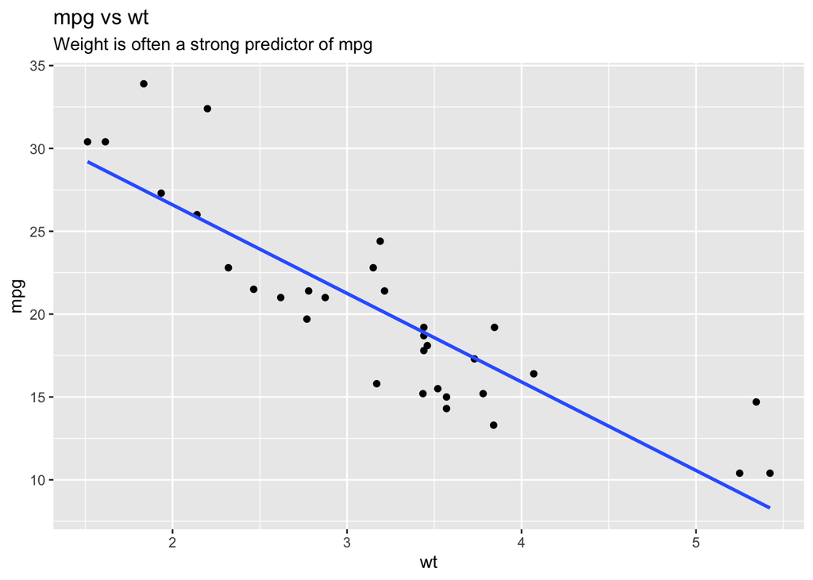

```r
ggplot(df, aes(wt, mpg)) +
geom_point() +
geom_smooth(method = "lm", se = FALSE) +
labs(title = "mpg vs wt", subtitle = "Weight is often a strong predictor of mpg")
```

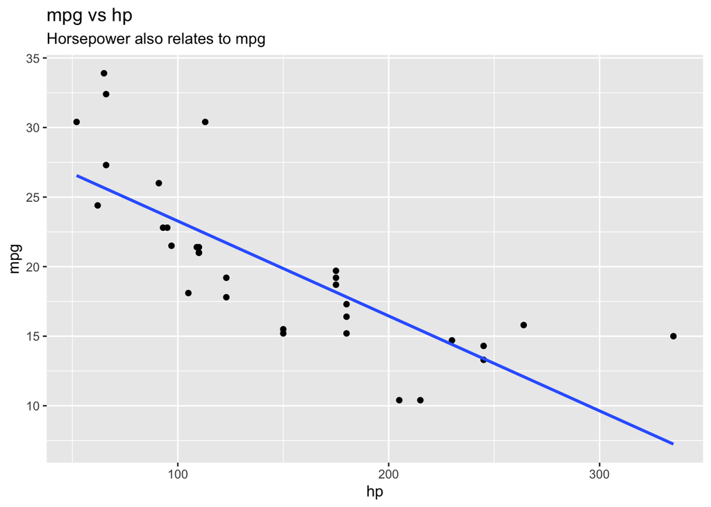

```r
ggplot(df, aes(hp, mpg)) +
geom_point() +
geom_smooth(method = "lm", se = FALSE) +
labs(title = "mpg vs hp", subtitle = "Horsepower also relates to mpg")
```

## 3.3 The simple linear regression model (one predictor)

### 3.3.1 Model specification

A simple linear regression with one predictor is:

$mpg_i=b_0+b_1⋅wt_i+ϵ_i$

where:

- $b_0$ is the intercept,
- $b_1$ is the slope for $wt$
- $\epsilon_i$ are residual errors.

### 3.3.2 Fit the model in R

```r
m1 <- lm(mpg ~ wt, data = df)
summary(m1)
```

```
##
## Call:
## lm(formula = mpg ~ wt, data = df)
##
## Residuals:
##     Min      1Q  Median      3Q     Max
## -4.5432 -2.3647 -0.1252  1.4096  6.8727
##
## Coefficients:
##             Estimate Std. Error t value Pr(>|t|)
## (Intercept)  37.2851     1.8776  19.858  < 2e-16 ***
## wt           -5.3445     0.5591  -9.559 1.29e-10 ***
## ---
## Signif. codes:  0 '***' 0.001 '**' 0.01 '*' 0.05 '.' 0.1 ' ' 1
##
## Residual standard error: 3.046 on 30 degrees of freedom
## Multiple R-squared:  0.7528, Adjusted R-squared:  0.7446
## F-statistic: 91.38 on 1 and 30 DF,  p-value: 1.294e-10
```

### 3.3.3 Interpret coefficients

- **Intercept (**$b_0$**):** predicted mpg when $wt$ = 0 (often not meaningful if $wt$=0 is outside the data range; but it is part of the line).
- **Slope (**$b_1$**):** expected change in mpg for a 1-unit increase in $wt$ (here, $wt$ is 1000 lbs in `mtcars` units).

### 3.3.4 Get a clean coefficient table

```r
tidy(m1, conf.int = TRUE)
```

| term | estimate | std.error | statistic | p.value | conf.low | conf.high |
| --- | --- | --- | --- | --- | --- | --- |
| (Intercept) | 37.285126 | 1.877627 | 19.857575 | 8.241799e-19 | 33.450500 | 41.119753 |
| wt | -5.344472 | 0.559101 | -9.559044 | 1.293959e-10 | -6.486308 | -4.202635 |

## 3.4 Model fit: R-squared and residual standard error

The `summary(m1)` output includes:

- **Multiple R-squared:** proportion of variance in mpg explained by wt.
- **Adjusted R-squared:** penalizes for extra predictors (important later).
- **Residual standard error (RSE):** typical size of prediction errors (in mpg).

Extract key fit metrics programmatically:

```r
glance(m1) %>%
select(r.squared, adj.r.squared, sigma, statistic, p.value, df.residual)
```

| r.squared | adj.r.squared | sigma | statistic | p.value | df.residual |
| --- | --- | --- | --- | --- | --- |
| 0.7528328 | 0.7445939 | 3.045882 | 91.37533 | 1.293959e-10 | 30 |

### 3.4.1 Predictions (fitted values) and residuals

```r
df_aug <- augment(m1)  # adds .fitted and .resid columns
head(df_aug)
```

| mpg | wt | .fitted | .resid | .hat | .sigma | .cooksd | .std.resid |
| --- | --- | --- | --- | --- | --- | --- | --- |
| 21.0 | 2.620 | 23.28261 | -2.2826106 | 0.04326896 | 3.067494 | 1.327407e-02 | -0.76616765 |
| 21.0 | 2.875 | 21.91977 | -0.9197704 | 0.03519677 | 3.093068 | 1.723963e-03 | -0.30743051 |
| 22.8 | 2.320 | 24.88595 | -2.0859521 | 0.05837573 | 3.072127 | 1.543937e-02 | -0.70575249 |
| 21.4 | 3.215 | 20.10265 | 1.2973499 | 0.03125017 | 3.088268 | 3.020558e-03 | 0.43275114 |
| 18.7 | 3.440 | 18.90014 | -0.2001440 | 0.03292182 | 3.097722 | 7.599578e-05 | -0.06681879 |
| 18.1 | 3.460 | 18.79325 | -0.6932545 | 0.03323551 | 3.095184 | 9.210650e-04 | -0.23148309 |

Plot fitted vs observed:

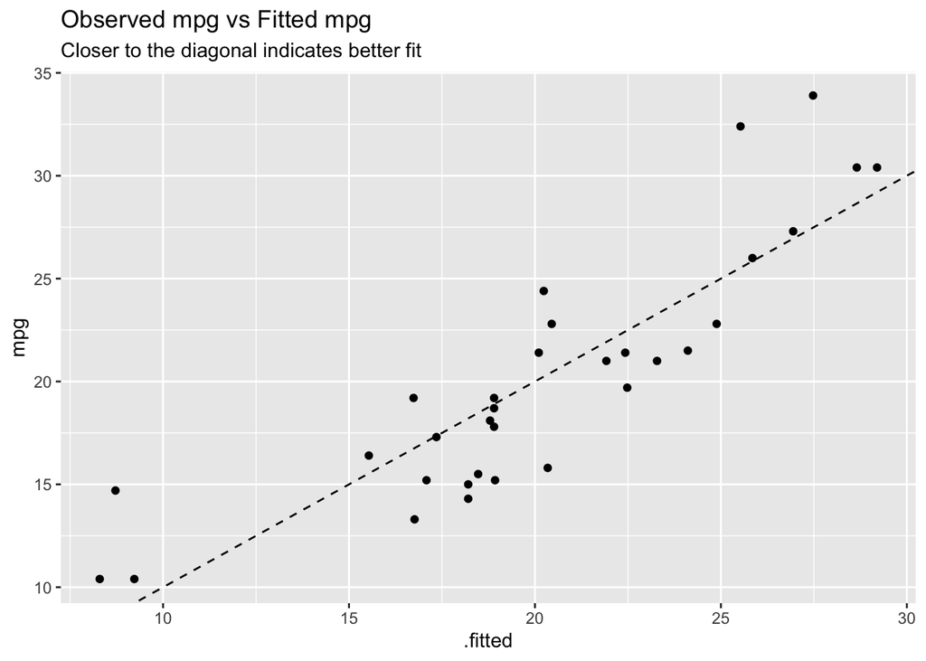

```r
ggplot(df_aug, aes(.fitted, mpg)) +
geom_point() +
geom_abline(slope = 1, intercept = 0, linetype = "dashed") +
labs(title = "Observed mpg vs Fitted mpg",
subtitle = "Closer to the diagonal indicates better fit")
```

# 4 Multiple regression (step-by-step model building)

Now we add horsepower:

$mpg_i=b_0+b_1⋅wt_i+b_2⋅hp_i+ϵ_i$

```r
m2 <- lm(mpg ~ wt + hp, data = df)
summary(m2)
```

```
##
## Call:
## lm(formula = mpg ~ wt + hp, data = df)
##
## Residuals:
##    Min     1Q Median     3Q    Max
## -3.941 -1.600 -0.182  1.050  5.854
##
## Coefficients:
##             Estimate Std. Error t value Pr(>|t|)
## (Intercept) 37.22727    1.59879  23.285  < 2e-16 ***
## wt          -3.87783    0.63273  -6.129 1.12e-06 ***
## hp          -0.03177    0.00903  -3.519  0.00145 **
## ---
## Signif. codes:  0 '***' 0.001 '**' 0.01 '*' 0.05 '.' 0.1 ' ' 1
##
## Residual standard error: 2.593 on 29 degrees of freedom
## Multiple R-squared:  0.8268, Adjusted R-squared:  0.8148
## F-statistic: 69.21 on 2 and 29 DF,  p-value: 9.109e-12
```

```r
tidy(m2, conf.int = TRUE)
```

| term | estimate | std.error | statistic | p.value | conf.low | conf.high |
| --- | --- | --- | --- | --- | --- | --- |
| (Intercept) | 37.22727012 | 1.59878754 | 23.284689 | 2.565459e-20 | 33.95738245 | 40.49715778 |
| wt | -3.87783074 | 0.63273349 | -6.128695 | 1.119647e-06 | -5.17191604 | -2.58374544 |
| hp | -0.03177295 | 0.00902971 | -3.518712 | 1.451229e-03 | -0.05024078 | -0.01330512 |

## 4.1 Interpreting coefficients in multiple regression (critical)

- The coefficient of `wt` in `m2` means: **“Expected change in mpg for a 1-unit increase in weight, *holding hp constant*.”**
- The coefficient of `hp` in `m2` means: **“Expected change in mpg for a 1-unit increase in horsepower, *holding wt constant*.”**

This “holding other variables constant” is what makes multiple regression powerful, and what makes interpretation different from simple regression.

## 4.2 Compare nested models (does adding hp improve the model?)

`m1` is nested within `m2` (m2 adds hp). We can use ANOVA (F-test) to compare:

```r
anova(m1, m2)
```

|  | Res.Df | RSS | Df | Sum of Sq | F | Pr(>F) |
| --- | --- | --- | --- | --- | --- | --- |
| 1 | 30 | 278.3219 | NA | NA | NA | NA |
| 2 | 29 | 195.0478 | 1 | 83.27418 | 12.38133 | 0.001451229 |

Interpretation:

- If p-value is small, adding `hp` significantly improves model fit (beyond wt alone).

## 4.3 AIC comparison (optional model selection tool)

Lower AIC is better (penalizes complexity):

```r
AIC(m1, m2)
```

|  | df | AIC |
| --- | --- | --- |
| m1 | 3 | 166.0294 |
| m2 | 4 | 156.6523 |

# 5 Regression assumptions: how to check them in R

A strong regression workflow is:

1. Fit the model
2. Inspect diagnostics
3. Identify violations
4. Adjust model or interpret cautiously

We’ll use `m2` (multiple regression) for diagnostics.

### 5.0.1 The “big four” diagnostic plots

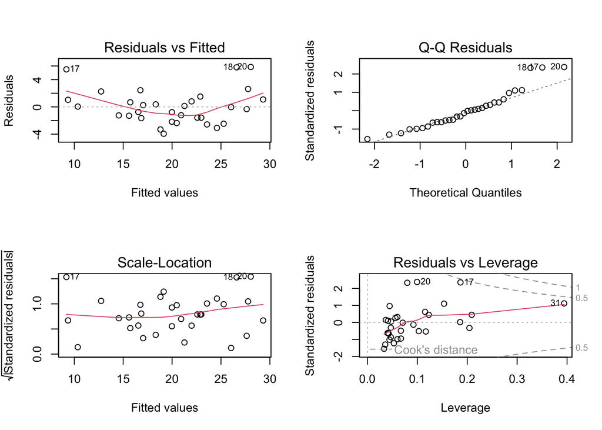

```r
par(mfrow = c(2, 2))
plot(m2)
```

```r
par(mfrow = c(1, 1))
```

### 5.0.2 These correspond to:

1. Residuals vs Fitted (linearity + mean-zero errors)
2. Normal Q-Q (normality of residuals)
3. Scale-Location (homoscedasticity)
4. Residuals vs Leverage (influential points)

We will now go one-by-one.

## 5.1 Linearity

### 5.1.1 What it means

The mean of Y should be a linear function of predictors (in the parameters). If the relationship is curved, a straight-line model is misspecified.

### 5.1.2 How to check

- Residuals vs fitted should show no systematic pattern (no curve).

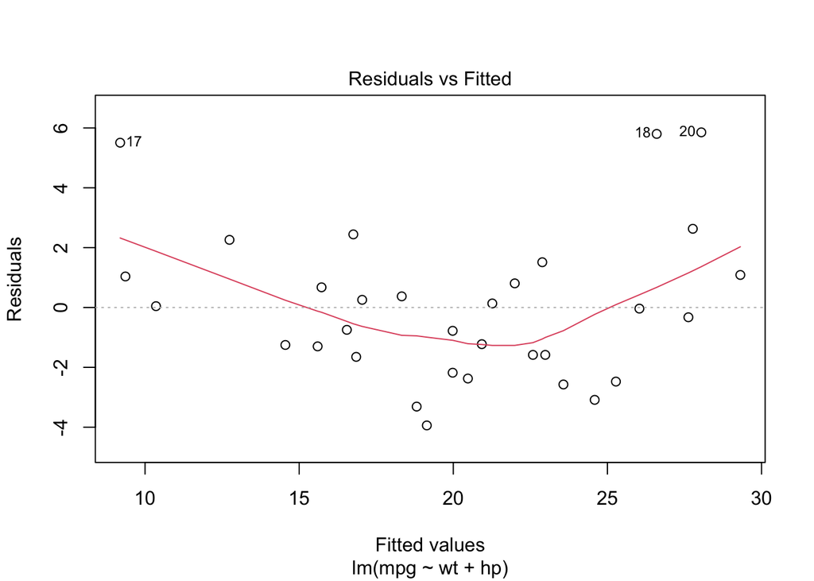

```r
plot(m2, which = 1)
```

**What to say:**

- If you see a clear curve or structure, linearity is likely violated.
- Potential responses: transform variables, add polynomial terms, or use splines (beyond today’s scope, but good to mention as next steps).

## 5.2 Independence

### 5.2.1 What it means

Residuals should be independent across observations.

### 5.2.2 When it matters

- Time series or longitudinal data: consecutive observations may be correlated.
- Clustered data: students within the same class, patients within the same hospital.

### 5.2.3 How to check (conceptual here)

With `mtcars`, independence is mostly a design assumption. In real studies, you check data collection design. For time-ordered data you can inspect residuals over time; for clustered data you may need mixed models.

*(We won’t run a formal autocorrelation test here, but we note the assumption and when it can fail.)*

## 5.3 Homoscedasticity (constant variance)

### 5.3.1 What it means

The spread of residuals should be roughly constant across fitted values.

### 5.3.2 How to check

- Look for “funnel” or “megaphone” shapes.
- Use Scale-Location plot.

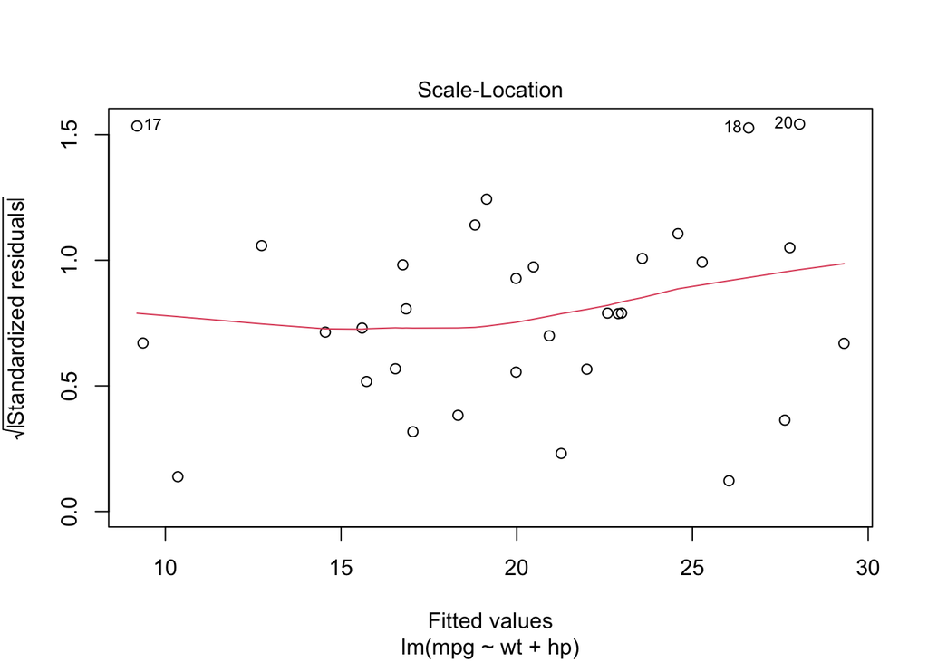

```r
plot(m2, which = 3)
```

**If violated:**

- Standard errors may be biased.
- Potential responses: transformations (e.g., log), robust standard errors, or modeling variance explicitly.

## 5.4 Normality of residuals

### 5.4.1 What it means

Residuals are approximately normally distributed.

This matters mostly for:

- small-sample inference on coefficients
- confidence intervals and p-values (less critical in large n due to CLT)

### 5.4.2 How to check

- Q-Q plot: points should roughly follow the line.

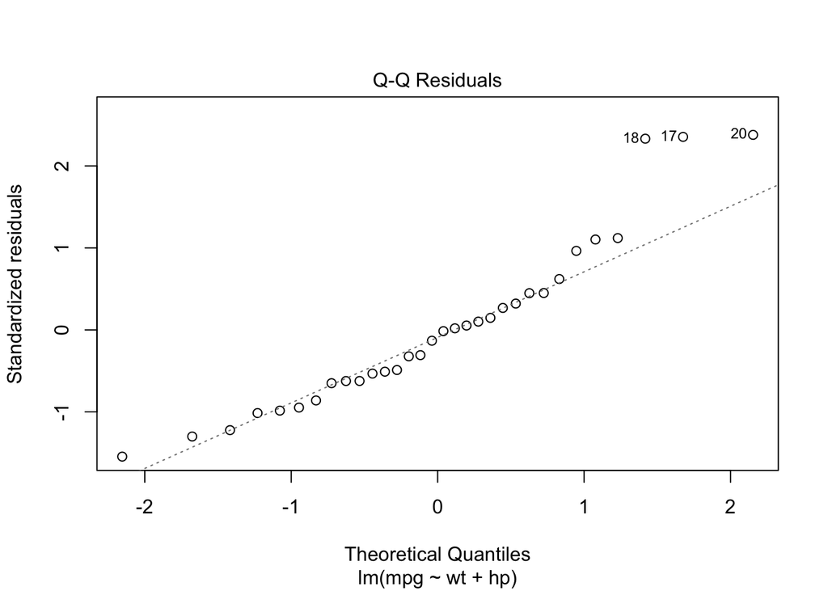

```r
plot(m2, which = 2)
```

Optional: Shapiro-Wilk test *(remember: can be too sensitive in large n and too weak in small n; prefer plots + context).*

```r
shapiro.test(resid(m2))
```

```
##
##  Shapiro-Wilk normality test
##
## data:  resid(m2)
## W = 0.92792, p-value = 0.03427
```

## 5.5 Outliers and influential observations

### 5.5.1 Concepts (important distinctions)

- **Outlier in Y:** unusual outcome value (large residual)
- **High leverage:** unusual X values (far from center in predictor space)
- **Influential point:** changes the model noticeably (often high leverage + large residual)

### 5.5.2 Cook’s distance (influence)

```r
cooks <- cooks.distance(m2)

# Quick look at the largest Cook's distances

sort(cooks, decreasing = TRUE)[1:6]
```

```
##         17         31         20         18         28         21
## 0.42361090 0.27203975 0.20839326 0.15742629 0.07353985 0.02791982
```

A common rule-of-thumb threshold:

$Di>4/n$

```r
n <- nrow(df)
which(cooks > (4 / n))
```

```
## 17 18 20 31
## 17 18 20 31
```

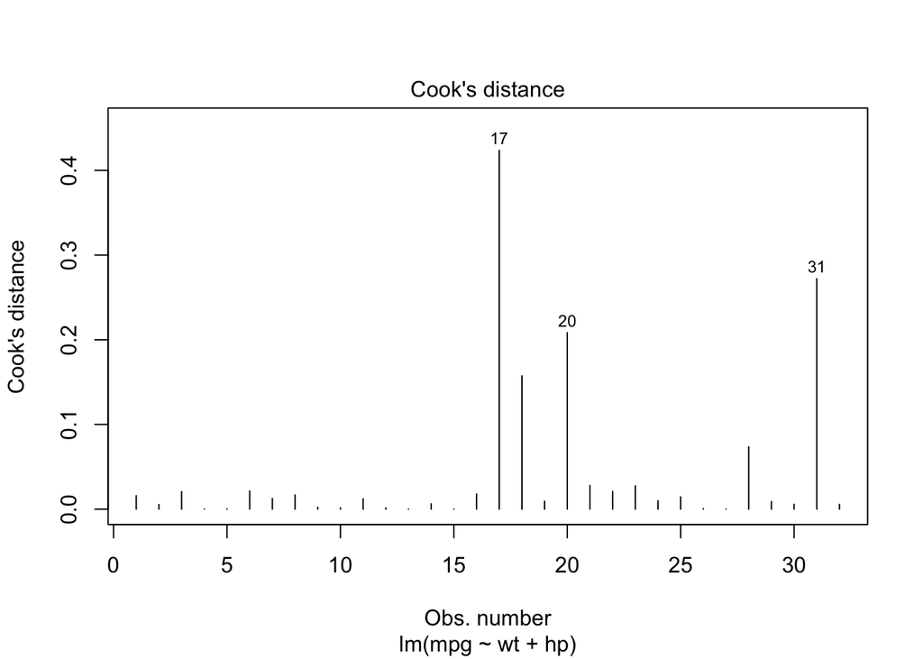

```r
# Plot Cook’s distance:
plot(m2, which = 4)
```

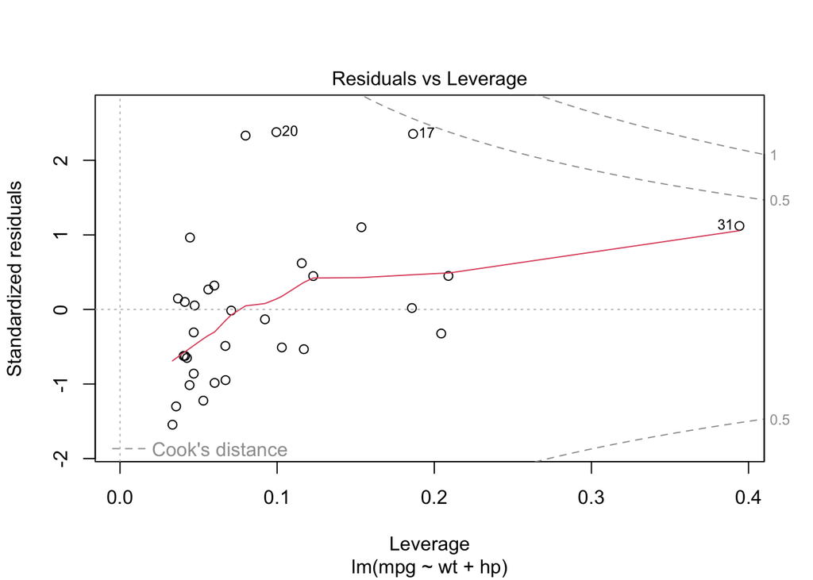

```r
# Leverage and influence plot
plot(m2, which = 5)
```

**How to handle influential points (what to teach):**

- Do not delete automatically.
- Investigate: data entry error? special case? legitimate observation?
- Report sensitivity: fit model with/without the point and compare conclusions.

## 5.6 Multicollinearity (multiple regression only)

### 5.6.1 What it means

Predictors are correlated with each other, making coefficient estimates unstable (large standard errors, sign flips).

### 5.6.2 How to check

Variance Inflation Factor (VIF):

```r
vif(m2)
```

```
##       wt       hp
## 1.766625 1.766625
```

Interpretation:

- Larger VIF indicates more multicollinearity.
- There is no single universal cutoff, but very high VIF suggests interpretation problems and unstable estimates.

# 6 Model refinement examples (guided options)

This section shows how you might *improve* a model when diagnostics indicate issues.

## 6.1 Add an interaction term (optional extension)

Sometimes the effect of weight depends on horsepower:

$mpg=b_0+b_1wt+b_2hp+b_3(wt⋅hp)+ϵ$

```r
m3 <- lm(mpg ~ wt * hp, data = df)
summary(m3)
```

```
##
## Call:
## lm(formula = mpg ~ wt * hp, data = df)
##
## Residuals:
##     Min      1Q  Median      3Q     Max
## -3.0632 -1.6491 -0.7362  1.4211  4.5513
##
## Coefficients:
##             Estimate Std. Error t value Pr(>|t|)
## (Intercept) 49.80842    3.60516  13.816 5.01e-14 ***
## wt          -8.21662    1.26971  -6.471 5.20e-07 ***
## hp          -0.12010    0.02470  -4.863 4.04e-05 ***
## wt:hp        0.02785    0.00742   3.753 0.000811 ***
## ---
## Signif. codes:  0 '***' 0.001 '**' 0.01 '*' 0.05 '.' 0.1 ' ' 1
##
## Residual standard error: 2.153 on 28 degrees of freedom
## Multiple R-squared:  0.8848, Adjusted R-squared:  0.8724
## F-statistic: 71.66 on 3 and 28 DF,  p-value: 2.981e-13
```

```r
anova(m2, m3)
```

|  | Res.Df | RSS | Df | Sum of Sq | F | Pr(>F) |
| --- | --- | --- | --- | --- | --- | --- |
| 1 | 29 | 195.0478 | NA | NA | NA | NA |
| 2 | 28 | 129.7615 | 1 | 65.28626 | 14.0875 | 0.0008108307 |

Interpretation:

- If interaction is significant, the slope of `wt` differs across levels of `hp` (or vice versa). Interpretation becomes conditional.

## 6.2 Centering predictors (helps interpretation; sometimes helps collinearity)

Centering makes the intercept meaningful at the *average* predictor values.

```r
df_centered <- df %>%
mutate(
wt_c = wt - mean(wt),
hp_c = hp - mean(hp)
)

m2c <- lm(mpg ~ wt_c + hp_c, data = df_centered)
summary(m2c)
```

```
##
## Call:
## lm(formula = mpg ~ wt_c + hp_c, data = df_centered)
##
## Residuals:
##    Min     1Q Median     3Q    Max
## -3.941 -1.600 -0.182  1.050  5.854
##
## Coefficients:
##             Estimate Std. Error t value Pr(>|t|)
## (Intercept) 20.09062    0.45846  43.822  < 2e-16 ***
## wt_c        -3.87783    0.63273  -6.129 1.12e-06 ***
## hp_c        -0.03177    0.00903  -3.519  0.00145 **
## ---
## Signif. codes:  0 '***' 0.001 '**' 0.01 '*' 0.05 '.' 0.1 ' ' 1
##
## Residual standard error: 2.593 on 29 degrees of freedom
## Multiple R-squared:  0.8268, Adjusted R-squared:  0.8148
## F-statistic: 69.21 on 2 and 29 DF,  p-value: 9.109e-12
```

```r
tidy(m2c, conf.int = TRUE)
```

| term | estimate | std.error | statistic | p.value | conf.low | conf.high |
| --- | --- | --- | --- | --- | --- | --- |
| (Intercept) | 20.09062500 | 0.45845476 | 43.822481 | 4.690472e-28 | 19.15297973 | 21.02827027 |
| wt_c | -3.87783074 | 0.63273349 | -6.128695 | 1.119647e-06 | -5.17191604 | -2.58374544 |
| hp_c | -0.03177295 | 0.00902971 | -3.518712 | 1.451229e-03 | -0.05024078 | -0.01330512 |

# 7 Logistic Regression (Categorical Outcomes)

## 7.1 When linear regression is not appropriate

Linear regression assumes a continuous outcome variable. When the outcome is binary or categorical (e.g., yes/no, pass/fail), linear regression is not suitable.

Logistic regression models the probability of an outcome instead.

## 7.2 Relationship to the chi-square test

- Chi-square asks: Is there an association?
- Logistic regression asks: How does each predictor change the probability?

Logistic regression can be seen as a model-based extension of the chi-square test that allows multiple predictors and effect size estimation.

# 8 Reporting regression results (templates)

## 8.1 Simple regression report template

“Weight significantly predicted fuel efficiency, $b=..., t(df)=..., p=..., R^2=...$”

## 8.2 Multiple regression report template

“A multiple linear regression was fit to predict mpg from weight and horsepower.  
The model explained $R^2=...$ of variance in mpg (Adj. $R^2=...$). Holding the other predictor constant, weight was associated with a change of … mpg per unit, and horsepower was associated with a change of … mpg per unit.”

You can extract the values for reporting:

```r
coefs <- tidy(m2, conf.int = TRUE)
fit   <- glance(m2)

coefs
```

| term | estimate | std.error | statistic | p.value | conf.low | conf.high |
| --- | --- | --- | --- | --- | --- | --- |
| (Intercept) | 37.22727012 | 1.59878754 | 23.284689 | 2.565459e-20 | 33.95738245 | 40.49715778 |
| wt | -3.87783074 | 0.63273349 | -6.128695 | 1.119647e-06 | -5.17191604 | -2.58374544 |
| hp | -0.03177295 | 0.00902971 | -3.518712 | 1.451229e-03 | -0.05024078 | -0.01330512 |

```r
fit %>% select(r.squared, adj.r.squared, sigma, statistic, p.value, df.residual)
```

| r.squared | adj.r.squared | sigma | statistic | p.value | df.residual |
| --- | --- | --- | --- | --- | --- |
| 0.8267855 | 0.8148396 | 2.593412 | 69.21121 | 9.109054e-12 | 29 |

# 9 Short exercises

## 9.1 Exercise 1: Correlation (quick)

1. Use `cor.test()` to compute Pearson and Spearman correlation between `wt` and `mpg`.
2. Compare results and explain any differences.

```r
cor.test(df$wt, df$mpg, method = "pearson")
```

```
##
##  Pearson's product-moment correlation
##
## data:  df$wt and df$mpg
## t = -9.559, df = 30, p-value = 1.294e-10
## alternative hypothesis: true correlation is not equal to 0
## 95 percent confidence interval:
##  -0.9338264 -0.7440872
## sample estimates:
##        cor
## -0.8676594
```

```r
cor.test(df$wt, df$mpg, method = "spearman", exact = FALSE)
```

```
##
##  Spearman's rank correlation rho
##
## data:  df$wt and df$mpg
## S = 10292, p-value = 1.488e-11
## alternative hypothesis: true rho is not equal to 0
## sample estimates:
##       rho
## -0.886422
```

## 9.2 Exercise 2: Build and diagnose your own regression

1. Fit `mpg ~ wt`
2. Fit `mpg ~ wt + hp`
3. Compare models using `anova(m1, m2)`
4. Inspect the 4 diagnostic plots for `m2` and write 2–3 sentences:
   - Is linearity plausible?
   - Any signs of heteroscedasticity?
   - Any influential points?

```r
m1_ex <- lm(mpg ~ wt, data = df)
m2_ex <- lm(mpg ~ wt + hp, data = df)

anova(m1_ex, m2_ex)
```

|  | Res.Df | RSS | Df | Sum of Sq | F | Pr(>F) |
| --- | --- | --- | --- | --- | --- | --- |
| 1 | 30 | 278.3219 | NA | NA | NA | NA |
| 2 | 29 | 195.0478 | 1 | 83.27418 | 12.38133 | 0.001451229 |

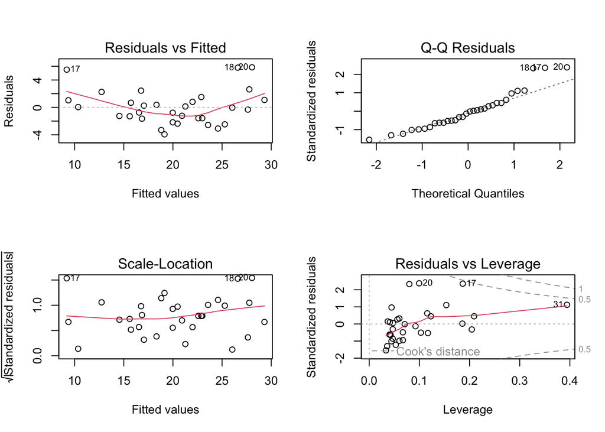

```r
par(mfrow = c(2, 2))
plot(m2_ex)
```

```r
par(mfrow = c(1, 1))
```

# 10 Appendix — Cheatsheet (what you should remember)

## 10.1 Correlation

- `cor(x, y, method="pearson"|"spearman"|"kendall")`
- `cor.test(x, y, ...)` for inference + CI

## 10.2 Regression basics

- `lm(y ~ x, data=df)`
- `summary(model)` for coefficients, R², tests
- `tidy(model)` and `glance(model)` for clean tables

## 10.3 Diagnostics

- `plot(model)` (4 key diagnostic plots)
- `cooks.distance(model)` for influence
- `car::vif(model)` for multicollinearity

  `shapiro.test(resid(model))` (use plots + context)